# Reproducible Research: Peer Assessment 1

Robert M Henke

Sunday, January, 18, 2015

### Loading and preprocessing the data

Reads data from file, `activity.csv` (located in folder `repdata_data_activity` of the working directory) into a data.table.

```r
library(data.table)

file_path <- paste0(getwd(),"/repdata_data_activity/activity.csv")

activity_DT <- fread(file_path, stringsAsFactors=FALSE)
```

Converts column named “date”" to Date data-type and adds a column named `dayOweek` cooresponding to the day of the week defined in column `date`.

```r
activity_DT <- activity_DT[,date:= as.Date(date, "%Y-%m-%d")][,dayOweek:=weekdays(date)]
```

### What is mean total number of steps taken per day?

Calculates total number of steps taken per day and graphs the results as a histogram.

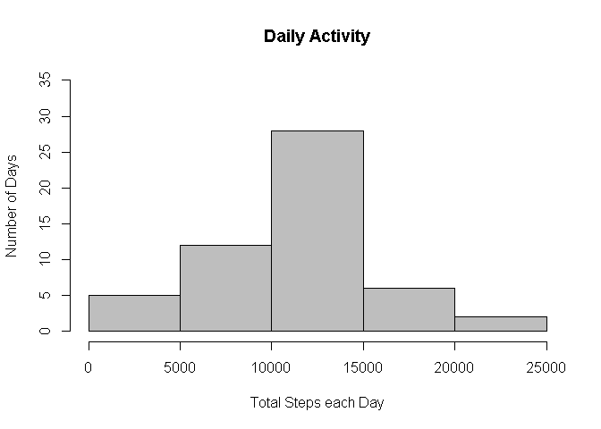

```r
total_steps_daily <- activity_DT[, list(total_steps=sum(steps)), by="date"]

hist(total_steps_daily$total_steps, main="Daily Activity",breaks=6, xlab="Total Steps each Day",
     ylab="Number of Days", col="grey"  , xlim = c(0,25000),ylim = c(0,35))
```

Calculates the mean and median of the total steps taken per day from the supplied dataset

```r
mean_step_day <- as.integer(total_steps_daily[, mean(total_steps,na.rm = TRUE )])

median_step_day <- as.integer(total_steps_daily[, median(total_steps,na.rm = TRUE)])
```

**Mean = 10766**

**Median = 10765**

### What is the average daily activity pattern?

Calculates the mean number of steps taken in each 5-minute interval across all days of the study.

```r
mean_step_5m_interval <- activity_DT[,list(mean_steps=mean(steps,na.rm = TRUE)), by="interval"]

max_row <- mean_step_5m_interval[,which.max(mean_steps)]

max_step <- mean_step_5m_interval[max_row, interval]
```

**The maximum steps occur at the 104th 5-minute interval coresponding to interval label 835**

Plots mean steps taken for each 5-minute interval across all days vs. each 5-minute interval expressed as the time of day

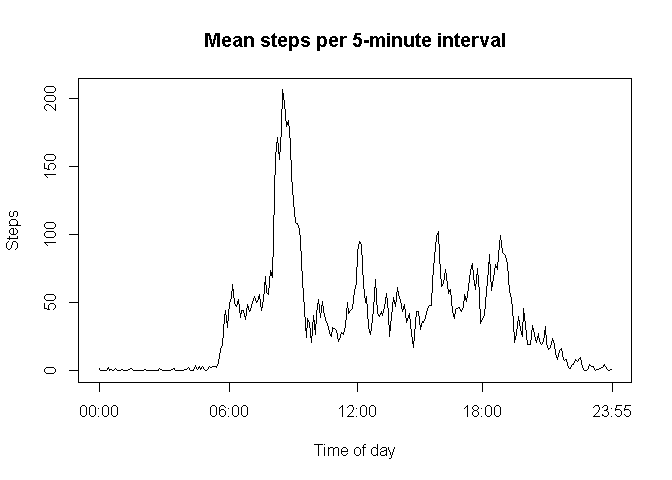

```r
plot(0:287, mean_step_5m_interval$mean_steps, type = "l", main = "Mean steps per 5-minute interval",
        ylab = "Steps", xlab = "Time of day", col="black",xaxt = "n")
        axis(side = 1, at = c(0,73,145,215,288), labels = c("00:00", "06:00", "12:00", "18:00","23:55"))
```

### Imputing missing values

Calculates the number of missing values.

```r
na_count <- nrow(activity_DT)- nrow(na.omit(activity_DT))
```

**Number of missing values= 2304**

The missing data is associated with missing weekdays. The missing data is imputated by replacing the missing weekdays with the corresponding weekday average. A weekday (Monday,Tuesday…) average is calculated and results are added to a new column, `mean_steps_dayOweek`, to the data.table. Missing `steps` column values are replaced with the corresponding value in the `mean_steps_dayOweek` column.

```r
mean_total_step_per_dayOweek <- activity_DT[,list(steps,date,interval,mean_steps_dayOweek=mean(steps,na.rm = TRUE)),by="dayOweek"]

mean_total_step_per_dayOweek <- mean_total_step_per_dayOweek[, steps:=ifelse(is.na(steps), mean_steps_dayOweek,steps)]
```

The columns are reorganized to match those in the source dataset.

```r
imputed_activity_DT <- mean_total_step_per_dayOweek[,list(steps,date,interval)]
```

Calculates total number of steps taken per day from the imputated dataset and graphs the results as a histogram.

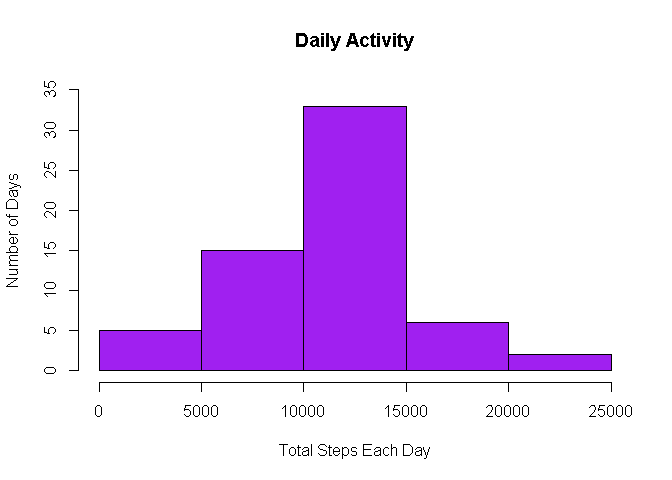

```r
imputed_total_steps_daily <- imputed_activity_DT[, list(total_steps=sum(steps)), by="date"]

hist(imputed_total_steps_daily$total_steps, main="Daily Activity",breaks=6, xlab="Total Steps Each Day",
     ylab="Number of Days", col="purple"  , xlim = c(0,25000),ylim = c(0,35))
```

Calculates the mean and median of the total steps taken per day from the imputated dataset

```r
Imean_step_per_day <- as.integer(imputed_total_steps_daily[, mean(total_steps, na.rm = TRUE)])

Imedian_step_per_day <- as.integer(imputed_total_steps_daily[, median(total_steps,na.rm = TRUE)])
```

**Imputed Mean= 10821**

**Imputed Median= 11015**

#### **SUMMARY**

| **Dataset** | **Mean** | **Median** |
| --- | --- | --- |
| Source | 10766 | 10765 |
| Imputed | 10821 | 11015 |
| Difference | 55 | 250 |

### Are there differences in activity patterns between weekdays and weekends?

```r
 mean_total_step_per_dayOweek <- mean_total_step_per_dayOweek[, day_type:=ifelse( (dayOweek=="Saturday") | (dayOweek=="Sunday") , "weekend", "weekday")]

mean_total_step_per_dayOweek$day_type <- as.factor(mean_total_step_per_dayOweek$day_type )

mean_total_step_per_dayOweek$interval_num <- 0:287
```

Plots the activity difference between weekdays and weekends.

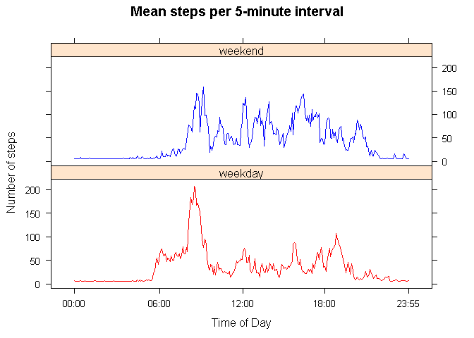

```r
wk_df <- mean_total_step_per_dayOweek[,list(mean_steps=mean(steps)), by="interval_num,day_type"]

library(lattice)
xyplot(mean_steps~interval_num | day_type,
       layout = c(1, 2),
       main="Mean steps per 5-minute interval",
       xlab="Time of Day",
       ylab="Number of steps",
       type="l",
       lty=1,
       group=day_type,
       col=c("red","blue"),
       scales=list(
                x=list(
                at=c(0,73,145,215,287),
                labels=c("00:00", "06:00", "12:00", "18:00","23:55") )),
       data=wk_df)
```